# EDA Case Competition

## Average Downtime By Maintenance Type

```r
# Calculate mean and median downtime by maintenance type
downtime_by_maintenance_type <- data %>%
  group_by(MAINTENANCE_TYPE_DESCRIPTION) %>%
  summarize(
    mean_downtime = mean(ACTUAL_WORK_IN_MINUTES, na.rm = TRUE),
    median_downtime = median(ACTUAL_WORK_IN_MINUTES, na.rm = TRUE),
    count = n()
  ) %>%
  arrange(desc(mean_downtime))

# View the result
print(downtime_by_maintenance_type)
```

```
## # A tibble: 6 × 4
##   MAINTENANCE_TYPE_DESCRIPTION   mean_downtime median_downtime   count
##   <chr>                                  <dbl>           <dbl>   <int>
## 1 "Breakdown Maintenance Order"          207.             205.       5
## 2 "Corrective Maintenance Order"         135.              60   134074
## 3 "Administrative Order"                 122.              60     6161
## 4 ""                                      88.4             48  1135469
## 5 "Capital Order"                         55.0             30       22
## 6 "Preventive Maintenance Order"          48.6             30   151533
```

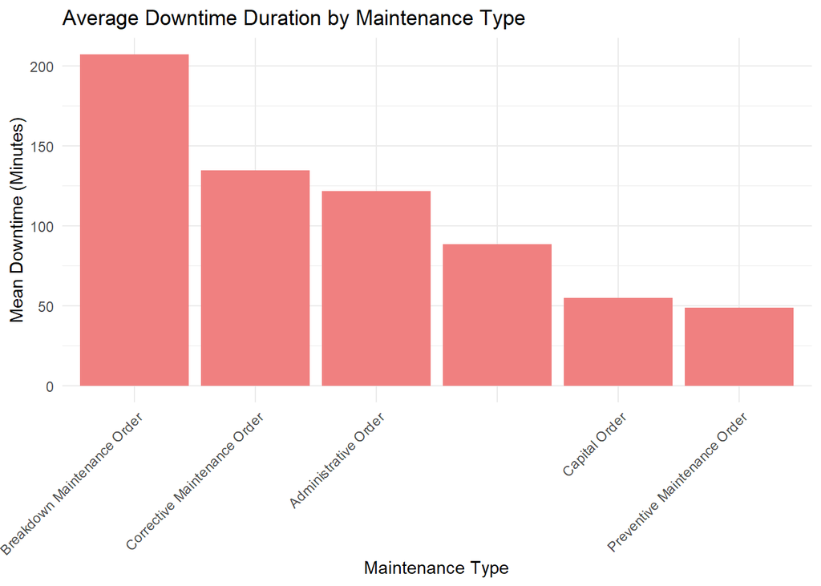

```r
# Plot downtime by maintenance type
ggplot(downtime_by_maintenance_type, aes(x = reorder(MAINTENANCE_TYPE_DESCRIPTION, -mean_downtime), y = mean_downtime)) +
  geom_bar(stat = "identity", fill = "lightcoral") +
  theme_minimal() +
  labs(
    title = "Average Downtime Duration by Maintenance Type",
    x = "Maintenance Type",
    y = "Mean Downtime (Minutes)"
  ) +
  theme(axis.text.x = element_text(angle = 45, hjust = 1))
```

**Insights:** The average downtime by maintenance type reveals significant differences in how long various types of maintenance activities take to resolve. Maintenance types with higher mean downtimes may indicate more complex repairs or inefficiencies in addressing certain issues. This information helps identify which types of maintenance tasks should be prioritized for process improvements to reduce overall downtime and enhance operational efficiency.

## Temporal Analysis

```r
# Convert date columns to Date format for analysis
# data$EXECUTION_START_DATE <- as.Date(data$EXECUTION_START_DATE, format = "%Y-%m-%d")

# Plot downtime trends by month or season (grouped by EXECUTION_START_DATE)
# ggplot(data, aes(x = EXECUTION_START_DATE, y = ACTUAL_WORK_IN_MINUTES)) +
#   geom_line() +
#   labs(title = "Downtime Trends Over Time", x = "Date", y = "Downtime (Minutes)")

# Aggregate by month
# data$month <- format(data$EXECUTION_START_DATE, "%Y-%m")  # Extract month and year
# monthly_downtime <- data %>%
#   group_by(month) %>%
#   summarise(total_downtime = sum(ACTUAL_WORK_IN_MINUTES, na.rm = TRUE))

# Plot aggregated data
# ggplot(monthly_downtime, aes(x = as.Date(month), y = total_downtime)) +
#   geom_line() +
#   labs(title = "Total Downtime by Month", x = "Date", y = "Total Downtime (Minutes)")
```